# final-mh

## Title: The State of Workers' Mental Health Perceptions in the Tech Industry

### Problem

This data exploration will address the problem of society's worsening mental health in the context of workers in the technology industry. Worldwide, mental health is a health problem to individuals. One's health and perception of their health may affect their job performance. With a field as highly demanding as the tech industry, the state of workers' mental health and perceptions deserves investigation.

### Background

10% of the global burden of disease is attributed to neuropsychiatric disorders. The leading contributors to years lived with disability are mental, neurological, and substance use disorders [(Global Mental Health, APA)](https://www.psychiatry.org/psychiatrists/international/global-mental-health). More locally, mental health in the United States continues to pose threats to people's wellbeing. Among adults, the prevelance of mental illness is increasing, suicidal ideation is increasing, and treatment is inaccessible [(Mental Health America)](https://www.mhanational.org/issues/state-mental-health-america). These statistics prove that we need to pay attention to mental health in our communities.

Reports have found that the tech industry's workplace culture tends to be less supportive of marginalized communities, including women [(Washington State Labor Education and Research Center and SEIU)](https://georgetown.southseattle.edu/sites/georgetown.southseattle.edu/files/2020-10/GenderDivideInTech-Final%5B5146%5D_1.pdf) and people of color [(Anil Dash)](http://anildash.com/2007/02/23/the_old_boys_cl/). In the summer of 2014, many notable tech companies including Google, Yahoo, and Facebook reported remarkably low statistics regarding a diverse staff and committed to do better. According to their Diversity Annual Report, as of 2020, Google's employees were 68% male and 54% white [(Google)](https://kstatic.googleusercontent.com/files/25badfc6b6d1b33f3b87372ff7545d79261520d821e6ee9a82c4ab2de42a01216be2156bc5a60ae3337ffe7176d90b8b2b3000891ac6e516a650ecebf0e3f866). Have these companies really delivered on their promises?

Krieger et al. found that class, race, and gender inequities in the healthcare workplace lead to risk of socially hazardous experiences [(International Journal of Health Services)](https://pubmed.ncbi.nlm.nih.gov/16524165/). Do these findings transcend the type of workplace? Socially isolating experiences can affect workers' mental health [(Journal of Interpersonal Violence)](https://journals.sagepub.com/doi/abs/10.1177/0886260508317182). How do these experiences affect workers specifically in the tech industry?

[Mental Health America](https://www.mhanational.org/blog/how-company-culture-may-be-impacting-your-mental-health) explored how company culture can impact employees' mental health. Emphasis was placed on the value of open and safe communication as well as a communicative managerial style. However, insiders have reported that the tech industry upholds unhealthy workforce habits [(Wharton UPenn)](https://knowledge.wharton.upenn.edu/article/silicon-valley-work-culture/). Among tech workers in China, controversy has risen regarding '996' culture. '996' culture is the expectation of Chinese workers from some tech companies to work from 9am to 9pm six days a week [(NY Times)](https://www.nytimes.com/2019/04/29/technology/china-996-jack-ma.html). How do these industry standards affect workers' mental health?

### Data Source

I will be analyzing the [SMI Mental Health in Tech Survey 2016](https://www.kaggle.com/osmi/mental-health-in-tech-2016?select=osmi-survey-2016_1479139902.json) dataset. In 2016, this survey was offered to workers worldwide in the tech industry. Questions include demographics such as age, gender, location, as well as treatment of mental health in the industry such as employers' discussion of mental health benefits, participants' comfort of disclosing about mental health conditions, and any mental health conditions participants felt comfortable sharing.

### Research Questions

These research questions aim to narrow down the answer to general question of what factors affect mental health perceptions and conditions in the tech industry?

1. **Do workers' perceptions of mental health differ by country?**

   Given the global issue of mental health discussed [earlier](https://www.psychiatry.org/psychiatrists/international/global-mental-health), mental health is persistent among cultures. The World Health Organization is increasing investment to mental health resources [(WHO)](https://www.who.int/health-topics/mental-health#tab=tab_1). It is interesting to wonder if culture affects the perception of mental health. By analyzing survey responses based on participants' locations, I can investigate cultural differences. Findings may suggest different needs for mental health resources based on the state of mental health in different cultures. Findings may also lead to investigations into different countries' workplace cultures to understand adaptive and maladaptive aspects of the industry.
2. **Do workers' perceptions of mental health differ by gender?**

   As discussed [earlier](https://georgetown.southseattle.edu/sites/georgetown.southseattle.edu/files/2020-10/GenderDivideInTech-Final%5B5146%5D_1.pdf), women tend to have different experiences than men in the tech workforce. Is there a correlation between gender and how workers experience conditions around mental health in their employment? Results may suggest the importance of challenging normal gender dynamics or changing how gender dynamics are currently treated in industry.
3. **Do workers' perceptions of mental health differ by age/generation?**

   Research suggests that members of different generations identify and conceptualize mental health and mental illness differently [(APA)](https://www.apa.org/monitor/2019/01/gen-z) [(Avera, Georgia Southern University)](https://digitalcommons.georgiasouthern.edu/cgi/viewcontent.cgi?article=1346&context=honors-theses). It is common for concepts to evolve from generation to generation. Analyzing responses based on age may provide insight into points of contention among workers, or between workers and employers.
4. **Overall, how do workers perceive mental health in the workforce?**

   Converse to the first three research questions investigating subpopulations, this question hopes to understand any general trends of perceptions of mental health in the workforce. Do workers' perceptions of mental health differ at all based on aspects of their identities, or are there any shared values among all workers?

```python
import pandas as pd
import scipy.stats as st
import numpy as np
import matplotlib as mpl
import matplotlib.pyplot as plt
```

```python
gcolors = ['mediumseagreen', 'powderblue', 'lightcoral', 'lightpink', 'goldenrod']
ticks_font = 14
axis_font = 16
title_font = 18
xwid = 8
ywid = 5
```

#### Cleaning Data

Renaming columns for ease of analysis while coding:

```python
base = pd.read_csv('mh_data.csv')
base.head()
base = base.drop(['Why or why not?', 'Why or why not?.1'], axis=1)
questions = base.columns
columns = ['SelfEmployed', 'NumEmployees', 'PrimarilyTechEmployer', 'PrimaryRoleTech', 'EmployerMHBenefits', 'KnowMHBenefits', 'DiscussedMH', 'ResourcesMH', 'AnonymityProtected', 'MHMedicalLeave',
            'MHEmployerConsq', 'PHEmployerConsq', 'DiscussMHCowrk', 'DiscussMHSuper', 'MHSeriousAsPH', 'CowrkNegConsqMH', 'MedCvrgMH', 'KnowMHResources', 'RevealMHDtoClients',
           'RevealedMHDtoClientsConsq', 'RevealedMHDtoCowrk', 'RevealedMHDtoCowrkConsq', 'ProductivityMH', 'TimeAffectedMH', 'HasPrevEmployers', 'PrevMHBenefits', 'PrevMHC',
          'PrevDiscussedMH', 'PrevResourcesMH', 'PrevAnonymityProtected', 'PrevMHEmployerConsq', 'PrevPHEmployerConsq', 'PrevDiscussMHCowrk', 'PrevDiscussMHSuper',
           'PrevMHSeriousAsPH', 'PrevCowrkNegConsqMH', 'PHInterview', 'MHInterview', 'MHIHurtCareer', 'CwrkNegViewYouMH', 'WillingShareFriendsMI', 'PrevBadHandledMHI',
           'OthersDiscussLessLikely', 'FamHistoryMI', 'PastMHD', 'CurrentMHD', 'YesWhichConditions', 'MaybeWhichConditions', 'MHDfromProf', 'FromProfWhichConditions',
          'SoughtTreatment', 'MHIInterferesWork', 'MHNotInterferesWork', 'Age', 'Gender', 'Country', 'USState', 'Country1', 'USState1', 'WorkPosition', 'WorkRemotely']
base.columns = columns
```

Cleaning data for consistency:

**Note:** Data is cleaned here regarding gender for data analysis. This method of sorting will be addressed in ethical concerns.

```python
base.SelfEmployed = base.SelfEmployed.replace([0,1], ['No', 'Yes'])
base.PrimarilyTechEmployer.value_counts()
base.PrimarilyTechEmployer = base.PrimarilyTechEmployer.replace([0.0, 1.0], ['No', 'Yes'])
base.PrimaryRoleTech = base.PrimaryRoleTech.replace([0.0, 1.0], ['No', 'Yes'])
base.MedCvrgMH = base.MedCvrgMH.replace([0.0, 1.0], ['No', 'Yes'])
base.HasPrevEmployers = base.HasPrevEmployers.replace([0,1], ['No', 'Yes'])
base.SoughtTreatment.value_counts()
base.SoughtTreatment = base.SoughtTreatment.replace([0,1], ['No', 'Yes'])
base.SoughtTreatment.value_counts()
base.Gender.value_counts()
base.Gender = base.Gender.str.lower().str.strip()
base.Gender = base.Gender.replace(dict.fromkeys(['m', 'man', 'cis male', 'male (cis)', 'male.', 'cis man', 'malr', 'dude', 'sex is male', 'mail', 'male (trans, ftm)',
                                                 'male/genderqueer', 'm|', 'cisdude'], 'male'))
base.Gender = base.Gender.replace(dict.fromkeys(['woman', 'f', 'cis female', 'cisgender female', 'fm', 'fem', 'cis-woman', 'female assigned at birth', 'transgender woman',
                                                'mtf', 'female-bodied; no feelings about gender', 'female (props for making this a freeform field, though)', 'female/woman',
                                                'i identify as female.', 'female or mulit-gender femme', 'genderqueer woman', 'transitioned, m2f', 'genderflux demi-girl'], 'female'))
base = base[(base.Gender == 'male') | (base.Gender == 'female')]
```

Understanding distribution of participants based on RQ and interested populations:

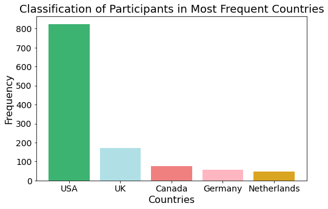

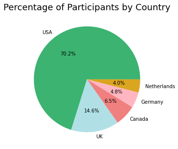

```python
countries_list = base.Country.value_counts().nlargest(5).index.tolist()
countries_abb = ['USA', 'UK', 'Canada', 'Germany', 'Netherlands']
base = base[base.Country.isin(countries_list)]
countries_num = base.Country.value_counts().tolist()
index = np.arange(len(countries_list))
plt.figure(figsize=(xwid, ywid))
plt.bar(x=index,height=countries_num,tick_label=countries_abb, color = gcolors)
plt.title("Classification of Participants in Most Frequent Countries", fontsize=title_font)
plt.xlabel("Countries", fontsize=axis_font)
plt.xticks(fontsize=ticks_font)
plt.yticks(fontsize=ticks_font)
plt.ylabel("Frequency", fontsize=axis_font)
plt.show()
plt.figure(figsize=(xwid, ywid))
plt.pie(countries_num, labels=countries_abb, autopct='%1.1f%%', colors=gcolors)
plt.title("Percentage of Participants by Country", fontsize=title_font)
plt.show()
```

Understanding gender demographics:

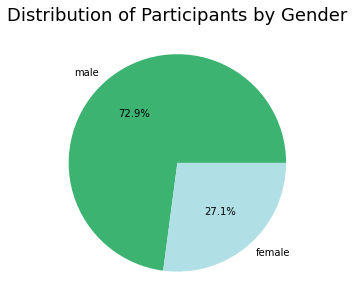

```python
gender_num = base.Gender.value_counts()
gender_list = base.Gender.value_counts().index.tolist()
index = np.arange(len(gender_list))
plt.figure(figsize=(xwid, ywid))
plt.pie(gender_num, labels=gender_list, autopct='%1.1f%%', colors=gcolors[:2])
plt.title("Distribution of Participants by Gender", fontsize=title_font)
plt.show()
```

Understanding age/generation demographics:

I have divided participants into generations based on their age in 2016 with generation bounds according to [Pew Research](https://www.pewresearch.org/fact-tank/2019/01/17/where-millennials-end-and-generation-z-begins/).

These age ranges are:

**Boomers:** 1946-1964

**Generation X:** 1965-1980

**Millenials:** 1981-1996

In 2016, these ages corresponded to:

**Boomers:** 52-70

3 participants were aged older than 70 and will be grouped with Boomers.

**Generation X:** 36-51

**Millenials:** 20-35

2 participants were aged 18 and 19 and will be grouped with Millenials.

[figure not shown]

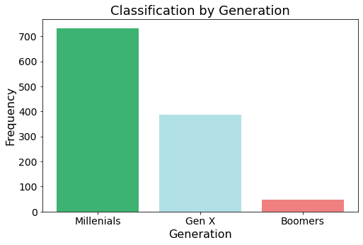

```
The p=value of the Shapiro-Wilk test performed on the ages of participants is 6.182674246822375e-20.
```

```python
#remove nonsensical outliers
base = base[base.Age != 323]
base = base[base.Age > 17]

age_range = np.arange(base.Age.min(), base.Age.max(), step=16)
age_range[3] = 73

temp = base.groupby(pd.cut(base.Age, age_range))['SelfEmployed'].count()

plt.figure(figsize=(xwid, ywid))
plt.hist(x=base.Age.value_counts(), bins=5, color=gcolors[0])
plt.title("Distribution by Age", fontsize=title_font)
plt.xlabel("Age", fontsize=axis_font)
plt.xticks(fontsize=ticks_font)
plt.yticks(fontsize=ticks_font)
plt.ylabel("Frequency", fontsize=axis_font)
plt.show()

plt.figure(figsize=(xwid, ywid))
plt.bar(x=np.arange(len(temp.values)),height=temp.values,tick_label=['Millenials', 'Gen X', 'Boomers'], color = gcolors[:3])
plt.title("Classification by Generation", fontsize=title_font)
plt.xlabel("Generation", fontsize=axis_font)
plt.xticks(fontsize=ticks_font)
plt.yticks(fontsize=ticks_font)
plt.ylabel("Frequency", fontsize=axis_font)
plt.show()

shap_test = st.shapiro(base.Age)
print(f"The p=value of the Shapiro-Wilk test performed on the ages of participants is {shap_test[1]}.")
```

According to the Shapiro-Wilk test that tests for normality, the p-value of age distribution is 6.18 * 10<sup>-20</sup>, which is less than the chosen alpha level of 0.05. Thus the null hypothesis that the data is normally distributed is rejected.

Based on the distribution of the data, the data is overly representative of young, American men. This will be acknowledged further in the ethical concerns.

# Data analysis

The following survey question results will be analyzed to answer the 3 research questions:

- Would you feel comfortable discussing a mental health disorder with your coworkers?
- Would you feel comfortable discussing a mental health disorder with your direct supervisor(s)?
- Would you be willing to bring up a physical health issue with a potential employer in an interview?
- Would you bring up a mental health issue with a potential employer in an interview?
- Do you feel that being identified as a person with a mental health issue would hurt your career?
- Do you think that team members/co-workers would view you more negatively if they knew you suffered from a mental health issue?

Run Chi-Square tests for Independence on question results based on subpopulations of gender, country of residence, and generation.

```python
headers = ['DiscussMHCowrk', 'DiscussMHSuper', 'PHInterview',
           'MHInterview', 'MHIHurtCareer', 'CwrkNegViewYouMH']
gender_pvalues = []
country_pvalues = []
age_pvalues = []
for header in headers:
    gender = pd.crosstab(base.Gender, base[header]).values.tolist()
    gender_stat = st.chi2_contingency(gender)
    gender_pvalues.append(gender_stat[1])

    country = pd.crosstab(base.Country, base[header]).values.tolist()
    country_stat = st.chi2_contingency(country)
    country_pvalues.append(country_stat[1])

    age = base.groupby(pd.cut(base.Age, age_range))[header]
    temp_age_array = []
    temp_age_arr = 0
    temp_first_arr = 0
    index = 0
    age_list = []
    for name, group in age:
        to_add = group.value_counts().sort_index().tolist()
        if (header == 'CwrkNegViewYouMH'):
            index += 1
        if (index == 3):
            to_add.insert(2, 0)
        age_list.append(to_add)
    age_data = (np.array(age_list, dtype=object))
    age_stat = st.chi2_contingency(age_data)
    age_pvalues.append(age_stat[1])
```

### Results

Mainly Chi-Square Test of Independence were conducted on this data because it compares the relationship between categorical variables and this data is categorical. These tests are run with a significance level of 0.05. The null hypothesis of these tests is that there is no relationship between the variables being compared. If a test result's p-value is less than my significance level of 0.05, I reject the null hypothesis and conclude that a relationship exists between the variables.

```python
results = pd.DataFrame({'Country': country_pvalues, 'Gender': gender_pvalues, 'Generation': age_pvalues}).transpose()
results.columns = headers
print("P-Values of Chi-Square Tests of Independence per Question and Subpopulation:")
results
```

```
P-Values of Chi-Square Tests of Independence per Question and Subpopulation:
```

|  | DiscussMHCowrk | DiscussMHSuper | PHInterview | MHInterview | MHIHurtCareer | CwrkNegViewYouMH |
| --- | --- | --- | --- | --- | --- | --- |
| Country | 0.327359 | 0.052723 | 0.008044 | 4.927002e-04 | 0.244041 | 0.327587 |
| Gender | 0.579740 | 0.732791 | 0.000008 | 4.014560e-08 | 0.016799 | 0.004643 |
| Generation | 0.776811 | 0.754201 | 0.268729 | 1.773379e-01 | 0.245291 | 0.123296 |

From these p-values, I can conclude that there is a significant relationship between:

- participants' gender and their belief that being identified as a person with a mental health condition would hurt their career
- participant's gender and their belief that their team members/co-workers would view them negatively if their team members/co-workers knew they had a mental health condition

Results regarding participants' perception of their mental and physical health conditions affecting interviews showed some significance and will be analyzed together later.

#### How Mental Health Conditions are Perceived to Hurt Careers

This analysis is regarding results to the question "Do you feel that being identified as a person with a mental health issue would hurt your career?". Results will be analyzed differently by participants' gender because there is significant difference between gender and results.

| Gender MHIHurtCareer | female | male |
| --- | --- | --- |
| Maybe | 112 | 373 |
| No, I don't think it would | 30 | 84 |
| No, it has not | 4 | 23 |
| Yes, I think it would | 143 | 319 |
| Yes, it has | 29 | 54 |

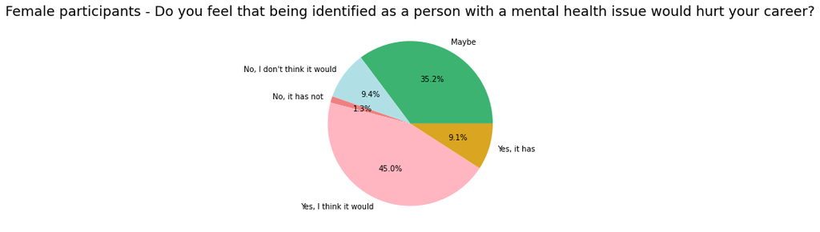

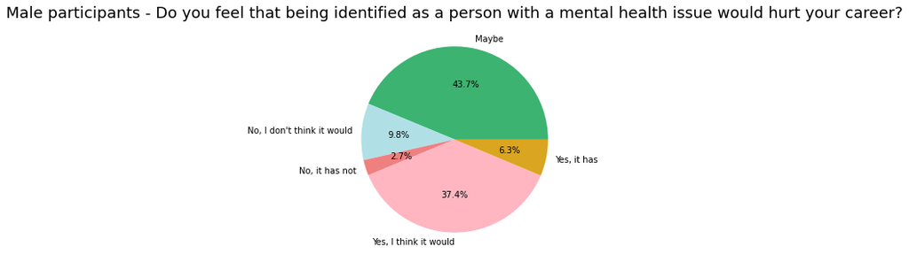

```python
display(pd.crosstab(base.MHIHurtCareer, base.Gender))
make_pie_plot("Female participants - Do you feel that being identified as a person with a mental health issue would hurt your career?", pd.crosstab(base.MHIHurtCareer, base.Gender).female.tolist(), ['Maybe', "No, I don't think it would", 'No, it has not', 'Yes, I think it would', 'Yes, it has'], gcolors)
make_pie_plot("Male participants - Do you feel that being identified as a person with a mental health issue would hurt your career?", pd.crosstab(base.MHIHurtCareer, base.Gender).male.tolist(), ['Maybe', "No, I don't think it would", 'No, it has not', 'Yes, I think it would', 'Yes, it has'], gcolors)
```

Whereas 54.1% of women think or know that having a mental health condition would hurt their career, 43.7% of men think or know that having a mental health condition would hurt their career. Additionally, 8.5% more men answered "maybe" to this question, suggesting more hesitation and uncertainty among male participants regarding how mental health conditions may affect their careers.

#### Perception of Oneself by Others regarding Mental Health Condition

This analysis is regarding results to the question "Do you think that team members/co-workers would view you more negatively if they knew you suffered from a mental health issue?". There was a significant different in results based on gender, but not country of resident or generation.

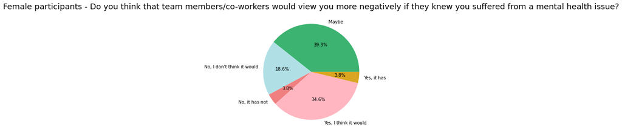

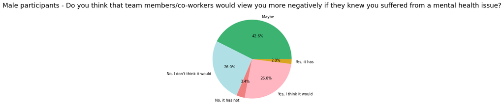

```python
make_pie_plot("Female participants - Do you think that team members/co-workers would view you more negatively if they knew you suffered from a mental health issue?", pd.crosstab(base.CwrkNegViewYouMH, base.Gender).female.tolist(), ['Maybe', "No, I don't think it would", 'No, it has not', 'Yes, I think it would', 'Yes, it has'], gcolors)
make_pie_plot("Male participants - Do you think that team members/co-workers would view you more negatively if they knew you suffered from a mental health issue?", pd.crosstab(base.CwrkNegViewYouMH, base.Gender).male.tolist(), ['Maybe', "No, I don't think it would", 'No, it has not', 'Yes, I think it would', 'Yes, it has'], gcolors)
```

Evidently from results, women are much more likely to think or know that their team members/co-workers would view them more negatively if they knew the participant had a mental health condition.

#### Discussing Mental Health in the Workforce

There was no significant difference between country of residence, gender, or generation of participants when asked if they would feel comfortable discussing a mental health disorder with coworkers or direct supervisors. Thus, I can analyze the results altogether without breaking results down by subpopulation.

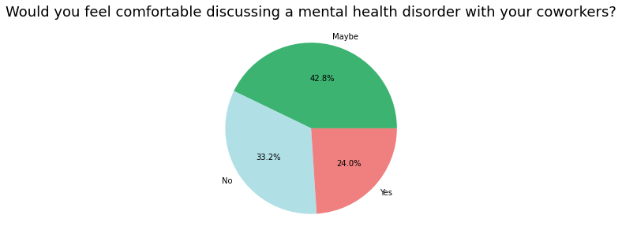

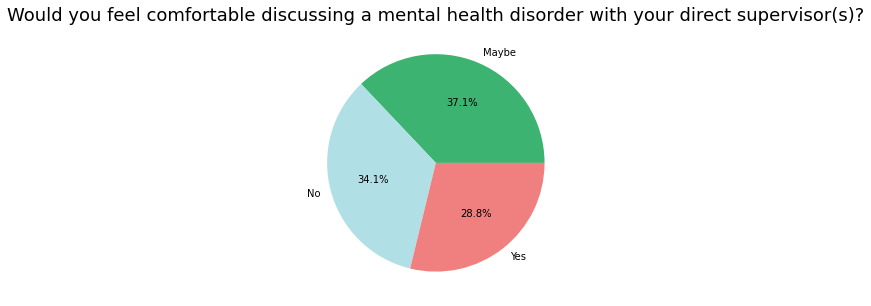

```python
make_pie_plot("Would you feel comfortable discussing a mental health disorder with your coworkers?", base.DiscussMHCowrk.value_counts().values, ['Maybe', 'No','Yes'], gcolors[:3])
make_pie_plot("Would you feel comfortable discussing a mental health disorder with your direct supervisor(s)?", base.DiscussMHSuper.value_counts().values, ['Maybe', 'No','Yes'], gcolors[:3])
```

These numbers are pretty similar. Overall, participants are like-minded in their thoughts on discussing mental health in the workforce whether it is with coworkers or supervisors.

#### Discussing Health Conditions in Job Interviews

```python
mil = np.arange(18, 36, 1).tolist()
genx = np.arange(36, 52,1).tolist()
boom = np.arange(52, 75, 1).tolist()

base.Age = base.Age.replace(dict.fromkeys(mil, 'Millenial'))
base.Age = base.Age.replace(dict.fromkeys(genx, "GenerationX"))
base.Age = base.Age.replace(dict.fromkeys(boom, "Boomer"))
```

```python
MHIlist = base.MHInterview.value_counts().values.tolist()
PHIlist = base.PHInterview.value_counts().values.tolist()
total_HIlist = []
total_HIlist.append(MHIlist)
total_HIlist.append(PHIlist)
interview_stats = st.chi2_contingency(total_HIlist)
print(f"The p-value of Chi-Square Test of Independence comparing results to questions \nasking about consequences of mental versus physical health conditions in job interviews is {interview_stats[1]}.")
```

```
The p-value of Chi-Square Test of Independence comparing results to questions
asking about consequences of mental versus physical health conditions in job interviews is 3.8271005318772313e-35.
```

This p-value suggests that from all responses, there is a difference in how willing participants are to bring up a health condition depending on if it's a physical or mental health condition.

Let's break this down further by subpopulations.

```python
gender_intvw = pd.crosstab([base.MHInterview, base.PHInterview], base.Gender).values.tolist()
gint_stat = st.chi2_contingency(gender_intvw)
country_intvw = pd.crosstab([base.MHInterview, base.PHInterview], base.Country).values.tolist()
country_stat = st.chi2_contingency(country_intvw)
age_intvw = pd.crosstab([base.MHInterview, base.PHInterview], base.Age).values.tolist()
age_stat = st.chi2_contingency(age_intvw)
intvw_df = pd.DataFrame({'Gender': gint_stat[1], 'Country': country_stat[1], 'Generation': age_stat[1]}, index=[0])
print("P-values of chi-square independence test comparing results to questions asking about \nmental and physical health condition consequences in interviews based on participants' demographics:")

intvw_df = intvw_df.transpose()
intvw_df.columns = ['p-value']
intvw_df
```

```
P-values of chi-square independence test comparing results to questions asking about
mental and physical health condition consequences in interviews based on participants' demographics:
```

|  | p-value |
| --- | --- |
| Gender | 4.632175e-07 |
| Country | 2.707512e-04 |
| Generation | 2.869828e-01 |

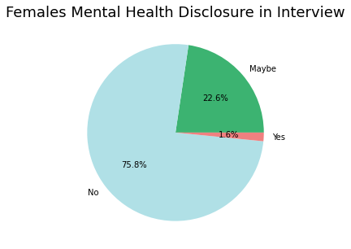

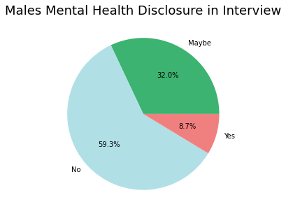

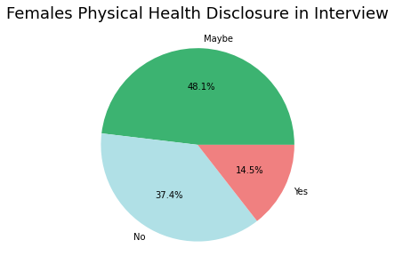

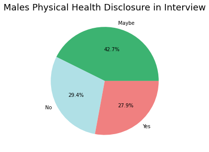

```python
def make_pie_plot(title, index, labels, colors):
    plt.figure(figsize=(xwid, ywid))
    plt.pie(index, labels=labels, autopct='%1.1f%%', colors=colors)
    plt.title(title, fontsize=title_font)
    plt.show()
make_pie_plot("Females Mental Health Disclosure in Interview", pd.crosstab(base.MHInterview, base.Gender).female.tolist(), ['Maybe', 'No','Yes'], gcolors[:3])
make_pie_plot("Males Mental Health Disclosure in Interview", pd.crosstab(base.MHInterview, base.Gender).male.tolist(), ['Maybe', 'No', 'Yes'], gcolors[:3])
make_pie_plot("Females Physical Health Disclosure in Interview", pd.crosstab(base.PHInterview, base.Gender).female.tolist(), ['Maybe', 'No','Yes'], gcolors[:3])
make_pie_plot("Males Physical Health Disclosure in Interview", pd.crosstab(base.PHInterview, base.Gender).male.tolist(), ['Maybe', 'No', 'Yes'], gcolors[:3])
```

Evidently, more men than women answered "Yes" or "Maybe" to being willing to disclose a mental *or* physical health condition in an interview.

| Country MHInterview | Canada | Germany | Netherlands | United Kingdom | United States of America |
| --- | --- | --- | --- | --- | --- |
| Maybe | 20 | 19 | 25 | 65 | 216 |
| No | 49 | 34 | 17 | 93 | 554 |
| Yes | 5 | 3 | 5 | 13 | 53 |

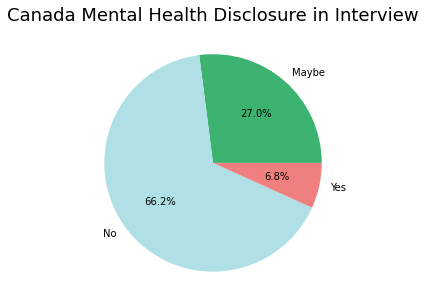

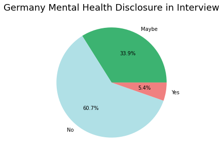

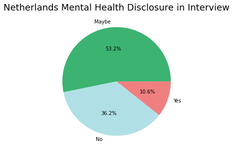

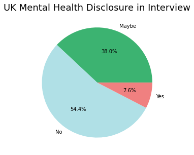

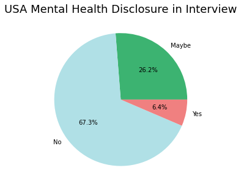

```python
display(pd.crosstab(base.MHInterview, base.Country))
make_pie_plot("Canada Mental Health Disclosure in Interview", pd.crosstab(base.MHInterview, base.Country)['Canada'].tolist(), ['Maybe', 'No','Yes'], gcolors[:3])
make_pie_plot("Germany Mental Health Disclosure in Interview", pd.crosstab(base.MHInterview, base.Country)['Germany'].tolist(), ['Maybe', 'No','Yes'], gcolors[:3])
make_pie_plot("Netherlands Mental Health Disclosure in Interview", pd.crosstab(base.MHInterview, base.Country)['Netherlands'].tolist(), ['Maybe', 'No','Yes'], gcolors[:3])
make_pie_plot("UK Mental Health Disclosure in Interview", pd.crosstab(base.MHInterview, base.Country)['United Kingdom'].tolist(), ['Maybe', 'No','Yes'], gcolors[:3])
make_pie_plot("USA Mental Health Disclosure in Interview", pd.crosstab(base.MHInterview, base.Country)['United States of America'].tolist(), ['Maybe', 'No','Yes'], gcolors[:3])
```

Answers were fairly consistent, except participants from the Netherlands were more hesitant and answered "Maybe" more than participants from other countries.

| Country MHInterview | Canada | Germany | Netherlands | United Kingdom | United States of America |
| --- | --- | --- | --- | --- | --- |
| Maybe | 20 | 19 | 25 | 65 | 216 |
| No | 49 | 34 | 17 | 93 | 554 |
| Yes | 5 | 3 | 5 | 13 | 53 |

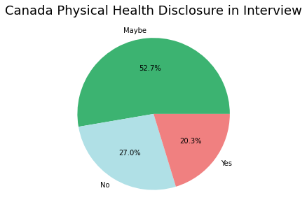

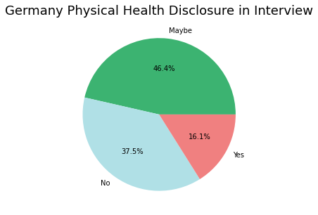

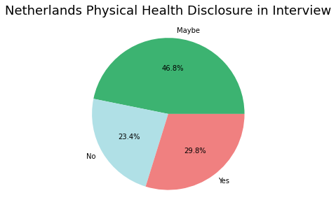

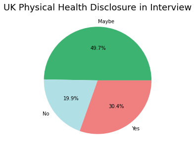

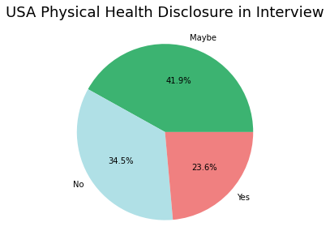

```python
display(pd.crosstab(base.MHInterview, base.Country))
make_pie_plot("Canada Physical Health Disclosure in Interview", pd.crosstab(base.PHInterview, base.Country)['Canada'].tolist(), ['Maybe', 'No','Yes'], gcolors[:3])
make_pie_plot("Germany Physical Health Disclosure in Interview", pd.crosstab(base.PHInterview, base.Country)['Germany'].tolist(), ['Maybe', 'No','Yes'], gcolors[:3])
make_pie_plot("Netherlands Physical Health Disclosure in Interview", pd.crosstab(base.PHInterview, base.Country)['Netherlands'].tolist(), ['Maybe', 'No','Yes'], gcolors[:3])
make_pie_plot("UK Physical Health Disclosure in Interview", pd.crosstab(base.PHInterview, base.Country)['United Kingdom'].tolist(), ['Maybe', 'No','Yes'], gcolors[:3])
make_pie_plot("USA Physical Health Disclosure in Interview", pd.crosstab(base.PHInterview, base.Country)['United States of America'].tolist(), ['Maybe', 'No','Yes'], gcolors[:3])
```

Compared to their responses to the last question, participants from each country were significantly more likely to disclose a physical health condition to an employer than a mental health condition.

| Age MHInterview | Boomer | GenerationX | Millenial |
| --- | --- | --- | --- |
| Maybe | 11 | 123 | 211 |
| No | 37 | 235 | 475 |
| Yes | 1 | 30 | 48 |

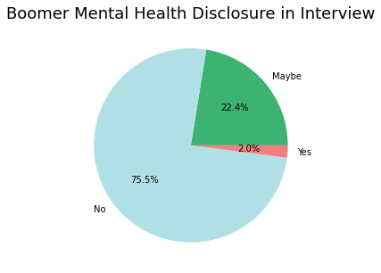

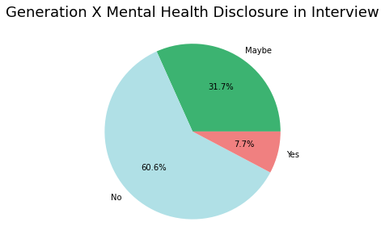

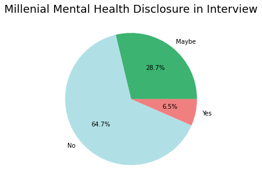

```python
display(pd.crosstab(base.MHInterview, base.Age))
make_pie_plot("Boomer Mental Health Disclosure in Interview", pd.crosstab(base.MHInterview, base.Age)['Boomer'].tolist(), ['Maybe', 'No','Yes'], gcolors[:3])
make_pie_plot("Generation X Mental Health Disclosure in Interview", pd.crosstab(base.MHInterview, base.Age)['GenerationX'].tolist(), ['Maybe', 'No','Yes'], gcolors[:3])
make_pie_plot("Millenial Mental Health Disclosure in Interview", pd.crosstab(base.MHInterview, base.Age)['Millenial'].tolist(), ['Maybe', 'No','Yes'], gcolors[:3])
```

Boomers were least likely to disclose a mental health condition in an interview.

| Age MHInterview | Boomer | GenerationX | Millenial |
| --- | --- | --- | --- |
| Maybe | 11 | 123 | 211 |
| No | 37 | 235 | 475 |
| Yes | 1 | 30 | 48 |

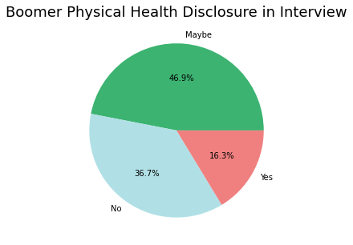

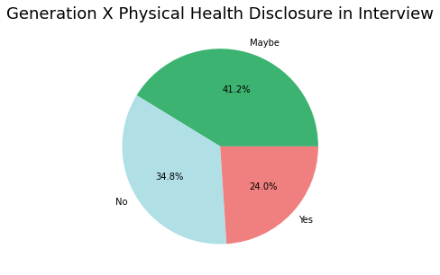

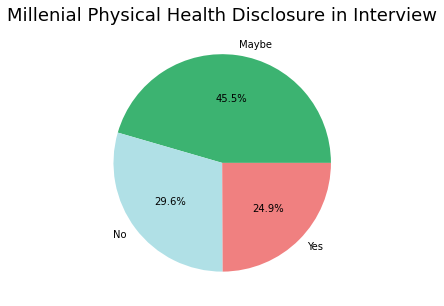

```python
display(pd.crosstab(base.MHInterview, base.Age))
make_pie_plot("Boomer Physical Health Disclosure in Interview", pd.crosstab(base.PHInterview, base.Age)['Boomer'].tolist(), ['Maybe', 'No','Yes'], gcolors[:3])
make_pie_plot("Generation X Physical Health Disclosure in Interview", pd.crosstab(base.PHInterview, base.Age)['GenerationX'].tolist(), ['Maybe', 'No','Yes'], gcolors[:3])
make_pie_plot("Millenial Physical Health Disclosure in Interview", pd.crosstab(base.PHInterview, base.Age)['Millenial'].tolist(), ['Maybe', 'No','Yes'], gcolors[:3])
```

All generations were significantly more likely to disclose a physical health condition than a mental health condition in an interview.

### Revisiting Research Questions

The research questions I set out to answer with this data were:

1. Do workers' perceptions of mental health differ by country?
2. Do workers' perceptions of mental health differ by gender?
3. Do workers' perceptions of mental health differ by age/generation?
4. Overall, how do workers perceive mental health in the workforce?

First I will address research question 2. In a few instances, there was a significant difference between survey question results based on the genders of the participants. From these results, I can suggest that more often than men, women think or know that having a mental health condition would hurt their career or negatively affect how their co-workers view them. Additionally, women are less likely than men to disclose either a physical or mental health condition during a job interview.

To address questions 1 and 3, this data suggests workers' perceptions of mental health generally do not differ by country or generation. Based on the statistical tests performed, there was not significant difference based on workers' country of residence of generation with which they belong to with one exception. I will first address this exception.

Results to these questions also technically differed based on country of residence. The difference in this data was that participants from the Netherlands greatly answered "Maybe" (instead of "Yes" or "No") to the question "Would you bring up a mental health issue with a potential employer in an interview?". Although these results suggest some hesitation or uncertainty among participants from the Netherlands, not many substantial questions can be drawn from these results.

Overall, there was no significant difference to results based on country of residence or generation. This leads into the answer to research question 4, regarding the overall trends of workers' perceptions of mental health in the workforce. For questions with no significant difference between identifiers and results, results could be analyzed altogether. This analysis yields results that participants are split in thirds ("Maybe", "No", "Yes") about if they would feel comfortable discussing a mental health condition with either their co-workers or direct supervisors. These mixed results may suggest other confounding variables among participants that affect their comfort discussing mental health conditions.

Another trend that occurred in the results was that overall, all participants were more likely to bring up a physical health condition than a mental health condition in a job interview. This suggests that among workers, physical health conditions are perceived to be more normal or acceptable in the workforce than mental health conditions.

Overall, there are trends that suggest discomfort or possible stigma around mental health in the tech workplace. This suggests the need for further intervention to improve workers' perception, and more importantly, treatment of mental health. This responsibility falls on the tech industry employers. As they improve the treatment of mental health in their workplaces, such as insurance benefits and workforce habits that are conducive to stable mental health, workers' perceptions will be affected by these observable and meaningful changes.

### Limitations and Concluding Ethical Concerns

As discussed in the analysis and visuals of participant demographics, the participants majorly consist of Millenial, American men. An ethical concern here is the lack of representation of participants of other identities. Even when analyzed by different demographics, this data may overrepresent the opinions of Millenial, American men. Furthermore, these demographics are reflective of an even larger problem: the underrepresented communities in the tech industry. As analysis of workers in the tech industry, I acknowledge the heterogeneous culture of the [tech industry that favors white men](https://recruitinginnovation.com/blog/diversity-in-tech/). Although this data is representative of this bias, I do not support or aim to perpetuate the current unfair workforce demographics.

Another limitation of this data is the handling of participants' gender in data cleaning. This survey collected gender dynamics with a fill-in-the-blank question. The responses included some participants identifying beyond the gender binary of male and female. However, there were not enough gender diverse participants to significantly offer any statistical conclusions. As a result, this data only considers male and female participants when analyzing responses based on gender. This is a dangerous limitation that overlooks many people's gender identities. This limitation may be resolved in future work with more aware and intentional collection of data. Furthermore, this limitation acknowledges the need for more representation for and fair treatment towards gender diverse people working in the tech industry.

Mental health is a sensitive topic to approach. An ethical concern is that analyzing people's mental health in the context of their work may minimize their value as individuals, perpetuating the harmful conflation of people as workers. Many of the countries represented in this survey data are capitalist, and I consider this factor worth the risk of the acknowledged ethical concern. Capitalism does not seem to be going anywhere, and analyzing the experience of people in the workforce may offer insight into supporting their experience and challenging barriers of the existing system. Regardless, in my reporting of the data I will be intentional in honoring that these perspectives come from individuals with jobs in the tech industry who maintain livelihoods beyond their work that may have affected their responses.

Another ethical concern regarding the sensitive nature of mental health is its treatment in the workplace. The data includes questions regarding the discussion of mental health in the workplace from employers. Although employers discussing mental health and mental health benefits is generally seen as a good thing, discussing the topic may be upsetting to people in the work setting. This topic must be approached with sensitivity.